# Sc-genetics: RolyPoly main

Pascal N. Timshel, Pers Lab

2018-01-31 22:20:12

# 1 Setup

```r
library(rolypoly)
library(tidyverse)
library(ggplot2)
```

```r
wd <- "/projects/timshel/sc-genetics/sc-genetics/src"
setwd(wd)
```

# 2 PARAMETERS

```r
dir.ldfiles <- "../data/rolypoly/EUR_LD_FILTERED_NONAN_R" # Linkage disequilibrium files
```

# 3 GWAS

REQUIRED COLUMNS IN DATA FRAME: c(‘chrom’, ‘pos’, ‘rsid’, ‘beta’, ‘se’, ‘maf’)

```r
file.gwas <- "../data/gwas_sumstats/body_BMI_Locke2015.gwassumstats.rolypoly_fmt.tab.gz"
df.gwas <- read_delim(file.gwas, delim="\t") # suppressMessages or use "col_types=cols()"
# TODO: check that chr is always integer
```

Rename columns

```r
df.gwas.rp <- df.gwas %>%
  rename(
    rsid = rsID,
    chrom = chr,
    maf = snp_maf)

# must be data frame for RolyPoly to run
df.gwas.rp %>% head
```

| rsid | beta | se | pval | maf | chrom | pos |
| --- | --- | --- | --- | --- | --- | --- |
| rs1000000 | 0.0001 | 0.0043 | 0.98140 | 0.2237 | 12 | 126890980 |
| rs10000010 | -0.0022 | 0.0029 | 0.43840 | 0.4901 | 4 | 21618674 |
| rs10000012 | -0.0096 | 0.0053 | 0.07009 | 0.1402 | 4 | 1357325 |
| rs10000013 | -0.0096 | 0.0043 | 0.02558 | 0.2296 | 4 | 37225069 |
| rs10000017 | -0.0038 | 0.0045 | 0.39840 | 0.2475 | 4 | 84778125 |
| rs10000023 | 0.0023 | 0.0037 | 0.53420 | 0.3857 | 4 | 95733906 |

# 4 Gene annotation

```r
file.gene_annot <- "../data/gene_annotations/gene_annotation.hsapiens_mmusculus_unique_orthologs.GRCh37.ens_v91.txt.gz"
df.gene_annot <- read_delim(file.gene_annot, col_types=cols(), delim="\t") # suppressMessages or use "col_types=cols()"
```

```r
df.gene_annot %>% head
```

| ensembl_gene_id | chromosome_name | start_position | end_position | mmusculus_homolog_ensembl_gene | mmusculus_homolog_orthology_confidence |
| --- | --- | --- | --- | --- | --- |
| ENSG00000138593 | 15 | 49280673 | 49338760 | ENSMUSG00000035093 | 1 |
| ENSG00000166351 | 21 | 14982498 | 15013906 | ENSMUSG00000095294 | 0 |
| ENSG00000168675 | 18 | 13217497 | 13652754 | ENSMUSG00000024544 | 1 |
| ENSG00000185272 | 21 | 15588451 | 15600693 | ENSMUSG00000032940 | 1 |
| ENSG00000155304 | 21 | 15743436 | 15755805 | ENSMUSG00000032932 | 1 |
| ENSG00000166200 | 15 | 49398268 | 49447858 | ENSMUSG00000027206 | 1 |

## 4.1 Filter genes: filter out non-autosomal genes (discard X, Y, contigs etc)

```r
n.discarded <- df.gene_annot %>% filter(!chromosome_name %in% 1:22) %>% nrow()
print(sprintf("Number of non-autosomal genes discarded: %s", n.discarded))
```

```
[1] "Number of non-autosomal genes discarded: 575"
```

```r
df.gene_annot.filtered <- df.gene_annot %>% filter(chromosome_name %in% 1:22)
```

# 5 Expression data

REQUIRED COLUMNS IN DATA FRAME: none (just cell-type/tissue names); rownames is genes

```r
file.expr <- "../data/expression/arc_lira/arc_lira-celltype_expr_ttest.hsapiens_orthologs.csv.gz"
df.expr <- read.csv(file.expr)
```

```r
df.expr %>% head
```

|  | Astrocyte_1 | Astrocyte_2 | Endothelial_1_Ependymal | Endothelial_2 | Endothelial_3 | Microglia_1 | Microglia_2 | Neuron_1 | Neuron_2 | Oligodendrocyte_1 | Oligodendrocyte_2_OPC | Oligodendrocyte_3 | Red_blood_cell | Tanycyte_1 | Tanycyte_2 | Unknown_1_Mix | Unknown_2_Mural | Unknown_3_Pars_tuberalis | Vascular_and_leptomeningial |
| --- | --- | --- | --- | --- | --- | --- | --- | --- | --- | --- | --- | --- | --- | --- | --- | --- | --- | --- | --- |
| ENSG00000206579 | -6.012774 | -7.275078 | -11.901776 | -11.89881125 | -11.897941 | -2.391353 | -11.897855 | 4.787803 | 4.990771 | 2.918348 | 3.601305 | 0.06692644 | -11.897838 | -6.7178789 | -0.626241 | -11.8979281 | -11.8975931 | 0.9992936 | -11.897606 |
| ENSG00000104237 | -5.690136 | -8.580350 | 8.142800 | 0.51972035 | -1.570439 | -8.578291 | -8.578197 | -8.578853 | -3.697335 | -8.580985 | -8.578592 | -8.57824061 | -8.578190 | -6.4886595 | -0.557483 | -8.5782237 | -8.5780990 | -8.5780355 | -8.578104 |
| ENSG00000164736 | -18.233578 | -18.228812 | -14.202361 | 16.39610805 | 12.772806 | -18.208887 | -18.207970 | -10.912072 | -18.211940 | -17.567202 | -18.211789 | -18.20839557 | -8.381592 | -16.9397074 | -18.208241 | -4.0806013 | 0.4105753 | -18.2064129 | -18.207071 |
| ENSG00000137547 | -5.959691 | 2.867242 | -5.943919 | 3.51254638 | 6.233629 | -5.027826 | -3.271133 | -8.475284 | 10.449950 | 2.550595 | 9.256203 | -2.21057418 | -20.101782 | -0.8617157 | 1.532345 | -1.5266392 | 1.3082472 | 0.9125281 | -4.231866 |
| ENSG00000120992 | -1.064668 | 3.723344 | 1.201903 | 4.96016058 | 4.754438 | -2.094062 | -1.435110 | -5.257581 | 1.558189 | -12.105154 | 1.746950 | -2.26623272 | -29.576361 | 3.1918716 | 4.111543 | -0.8276763 | 2.3001636 | 1.3123688 | 0.887920 |
| ENSG00000187735 | -10.367237 | -3.393385 | 5.689519 | -0.02579175 | 3.517372 | -5.512061 | -5.471468 | -7.306722 | 7.758133 | 3.145991 | 4.125005 | -1.27490841 | -26.161343 | 7.5081637 | 10.841984 | -4.5418057 | 1.8935254 | 0.4306365 | -1.282070 |

## 5.1 Filter genes (based on `df.gene_annot.filtered`, e.g. autosomal)

```r
bool.expr_genes_filtered <- rownames(df.expr) %in% df.gene_annot.filtered$ensembl_gene_id
df.expr.filtered <- df.expr[bool.expr_genes_filtered, ]
```

# 6 Numerical transformation of expression data (square values)

1. 1. z-scores for each gene (across cells) “cell’s relative expression of each gene, in comparison to all other cells:
2. Square to avoid negative values.

```r
### Square values
df.expr.filtered.rp <- df.expr.filtered^2
```

# 7 Block annotation: window size, etc

REQUIRED COLUMNS IN DATA FRAME: c(‘chrom’, ‘start’, ‘end’, ‘label’)

```r
WINDOW_SIZE <- 10*10^3 # 10kb
df.block_annotation <- df.gene_annot.filtered %>% transmute(
  label=ensembl_gene_id,
  chrom=chromosome_name,
  start=start_position,
  end=end_position
)
df.block_annotation %>% head
```

| label | chrom | start | end |
| --- | --- | --- | --- |
| ENSG00000138593 | 15 | 49280673 | 49338760 |
| ENSG00000166351 | 21 | 14982498 | 15013906 |
| ENSG00000168675 | 18 | 13217497 | 13652754 |
| ENSG00000185272 | 21 | 15588451 | 15600693 |
| ENSG00000155304 | 21 | 15743436 | 15755805 |
| ENSG00000166200 | 15 | 49398268 | 49447858 |

# 8 Rolling rolypoly

We include all the previously described data into the main rolypoly function call. This function has many parameters to tinker with, however, should run fine with the defaults. Most importantly consider the number of bootstrap iterations to get accurate standard errors. We usually use at least 200.

```r
df.gwas.rp.test <- df.gwas.rp %>% slice(1:1000)
```

```r
library(doParallel)
registerDoParallel(40) # half of the number of cores
getDoParWorkers()
```

```
[1] 40
```

```r
knitr::purl("rolypoly_main.Rmd", output = "rolypoly_main.R", documentation = 2)
```

```
processing file: rolypoly_main.Rmd
```

[output not shown]

```
output file: rolypoly_main.R
```

```
[1] "rolypoly_main.R"
```

```r
# message = FALSE
# TODO: run with "highres" data
rm(rp)
```

```r
system.time(rp <- rolypoly_roll(
  gwas_data = as.data.frame(df.gwas.rp),
  block_annotation = as.data.frame(df.block_annotation),
  block_data = as.data.frame (df.expr.filtered.rp),
  ld_folder = dir.ldfiles,
  bootstrap_iters = 50,
  gwas_link_parallel = T,
  bootstrap_parallel = T
))
```

```r
# save.image(file="out.rolypoly_main-NB.RData")
# load(file="out.rolypoly_main-SCRIPT.RData")
```

# 9 Parallelization: Inference on other expression data set

Without any parallelization rolypoly could take a couple hours to run. Much of the computation is spent linking SNPs to genes and reading in LD information. If one provides the a rolypoly object to the rolypoly parameter of the `rolypoly_roll` function call and a new object of block data, then only inference is performed. For example with the previous rolypoly object we would run inference on a new expression data set with the following call (assuming that the gene labels did not change between datasets).

```r
# rp.new <- rolypoly_roll(
#   # some new set of expression data
#   rolypoly = rp,
#   block_data = new_sim_expression_data_normalized
# )
```

Thus, one can run precomputation (slow) once and then rerun inference (faster) on various expression matrices more quickly.

## 9.1 Results

```r
rp$full_results$parameters %>% sort
```

```
          Oligodendrocyte_3    Unknown_3_Pars_tuberalis                 Microglia_1               Unknown_1_Mix                 Astrocyte_1
              -3.541850e-09               -3.123757e-09               -2.017387e-09               -1.516252e-09               -1.258116e-09
      Oligodendrocyte_2_OPC                  Tanycyte_1                    Neuron_2                 Microglia_2               Endothelial_2
              -1.222446e-09               -9.987471e-10               -7.325409e-10               -3.842015e-10               -1.660112e-10
            Unknown_2_Mural                    Neuron_1           Oligodendrocyte_1               Endothelial_3     Endothelial_1_Ependymal
              -5.321232e-11                1.288960e-10                1.335040e-10                1.909797e-10                5.209578e-10
                Astrocyte_2 Vascular_and_leptomeningial              Red_blood_cell                  Tanycyte_2                   intercept
               6.702676e-10                2.307982e-09                3.191862e-09                4.526205e-09                3.654641e-07
```

Better yet, there’s a data frame with results from the bootstrap runs that calculates standard errors for these paramter estimates, p-values, and 95% confidence intervals.

|  | annotation | bootstrap_estimate | bootstrap_error | bt_value | bp_value | bias_corrected_estimate | CI_lo | CI_hi |
| --- | --- | --- | --- | --- | --- | --- | --- | --- |
| 1 | Red_blood_cell | 3.343991e-09 | 1.068242e-09 | 3.1303693 | 0.0008729334 | 3.039732e-09 | 1.146209e-09 | 4.908881e-09 |
| 2 | Vascular_and_leptomeningial | 2.373192e-09 | 1.516211e-09 | 1.5652124 | 0.0587665546 | 2.242773e-09 | -5.223586e-10 | 5.811896e-09 |
| 3 | Tanycyte_2 | 4.004054e-09 | 2.961784e-09 | 1.3519063 | 0.0882026482 | 5.048356e-09 | -3.879443e-10 | 9.757031e-09 |
| 4 | Endothelial_1_Ependymal | 5.023702e-10 | 5.204173e-10 | 0.9653219 | 0.1671918083 | 5.395454e-10 | -4.555156e-10 | 1.479461e-09 |
| 5 | intercept | 2.963996e-07 | 6.409086e-07 | 0.4624678 | 0.3218729605 | 4.345286e-07 | -1.071378e-06 | 1.417155e-06 |
| 6 | Oligodendrocyte_1 | 8.668086e-11 | 2.031365e-10 | 0.4267125 | 0.3347943785 | 1.803271e-10 | -3.524268e-10 | 3.829792e-10 |

For visualization, one can use the following function which plots the estimate with 95% confidence intervals,

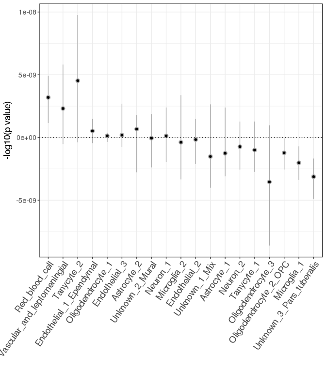

Additionally, we plot the $-log10(p)$ to rank tissues by the strength of their association

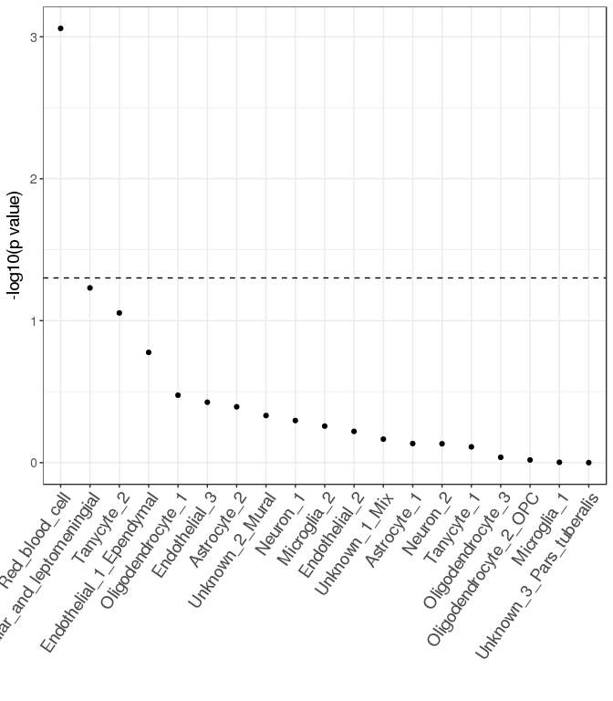

These functions return ggplot2 objects so free to manipulate them as such.

```r
########################################################################################################################
########################################################################################################################
################################################## LEFTOVER ############################################################
```

Check that all genes are found in the gene annotation file Ortherwise we would have to filter out genes not in the gene annotation file…